# SA Diesel Price Report - June 2022

Zebrina Solutions

2022-06-01

### **Introduction**

This report serves to visualize the key components that are used to build up the price of Diesel (50ppm) on a monthly basis in South Africa. It looks at the trends in two key inputs to the pricing structure, specifically that of the price of Brent crude, as well as the USD ZAR exchange rate.

The figures displayed here in this report are based on a month-to-month period, with the month starting on the 1st, and ending on the last day of that specific month.

In terms of the pricing structure implemented by the Central Energy Fund (CEF), who regulates and controls the official fuel pricing in South Africa, their figures are usually captured from the last Wednesday, Thursday or Friday of the prior month, to a period of 30 or 31 days following that. This is due to fuel pricing officially changing at midnight on the 1st Wednesday of every month.

Due this difference, the figures presented here will never match exactly what the CEF publishes, however the difference is usually just a few ZAR cents. The goal of this report is to visualize medium-to-long term trends, and their impact.

#### Diesel Fuel Price Structure

- **Basic Fuel Price** + **Taxes** (Fuel, Road Accident Fund, Customs & Excise, IP Tracer) + **Slate** + Regulated **Margins** (Wholesale, Secondary Storage, Secondary Distribution) + MDZ **Zone Differential** (1A or 2A or 3A etc) = **Wholesale List Price**
- BFP is primarily influenced by 2 key factors: USD ZAR exchange rate & price of Brent crude.

#### Data Sources

- South Africa Central Energy Fund [CEF](https://www.cefgroup.co.za/petrol-price/monthly-press-release/2022)
- U.S. Energy Information Administration [EIA](https://www.eia.gov/dnav/pet/hist/rbrteD.htm)

#### Data Tools

- Excel for cleaning & processing.
- R for analysis & visualizations.

#### Licensing

- Visualizations are free to use. Credit to Zebrina Solutions would be appreciated.

### **Wholesale List Price (WSLP)**

- 124% increase in BFP year-on-year.
- The Slate levy continues to be applied monthly (since Aug 2021).
- The 150 CPL ZAR reduction of the Fuel Tax is now in its third month. In July, the reduction will be reduced to just 75 CPL ZAR, with the plan to remove the reduction completely in August 2022.
- The Road Accident Fund (RAF) levy continues to be applied at its nominal rate of 218 CPL ZAR.

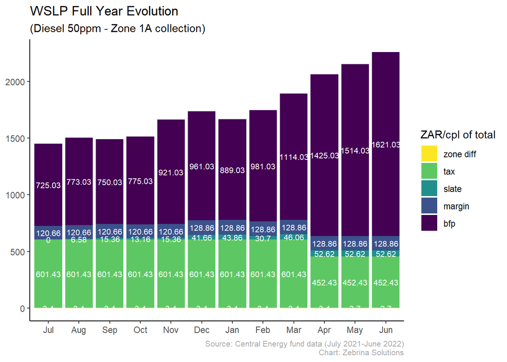

- BFP now compromises 71.8% of total WSLP (up from 48.53% in Jun 2021).
- Taxes now compromise just 20.04% (excl. slate) of total WSLP (down from 42.67% in Jun 2021).

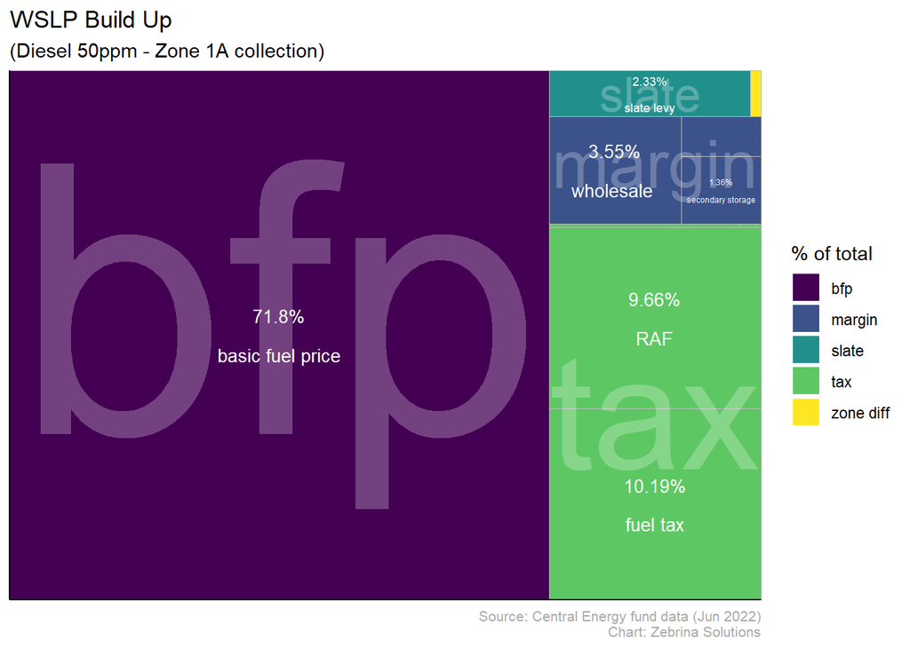

### **USD/ZAR Exchange Rate**

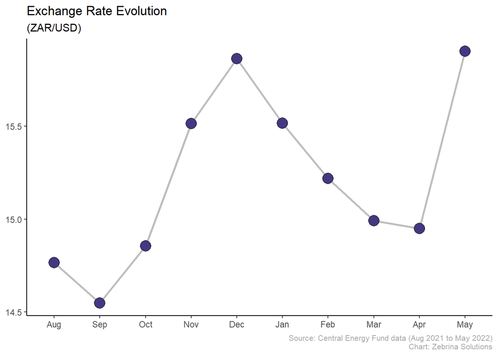

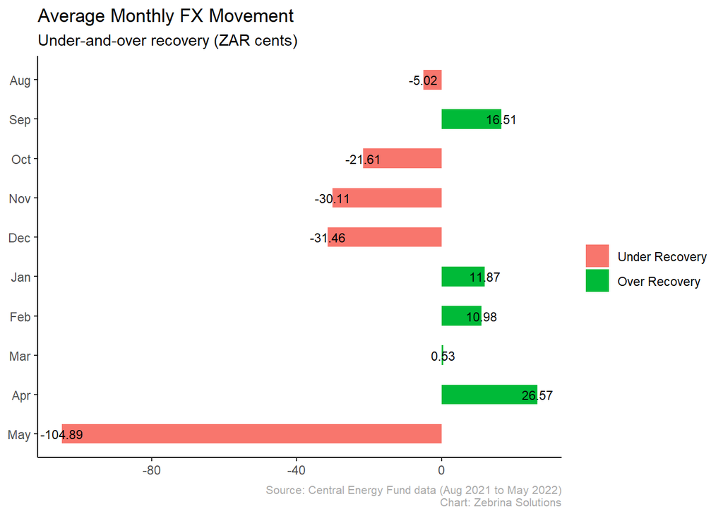

### **Brent Crude**

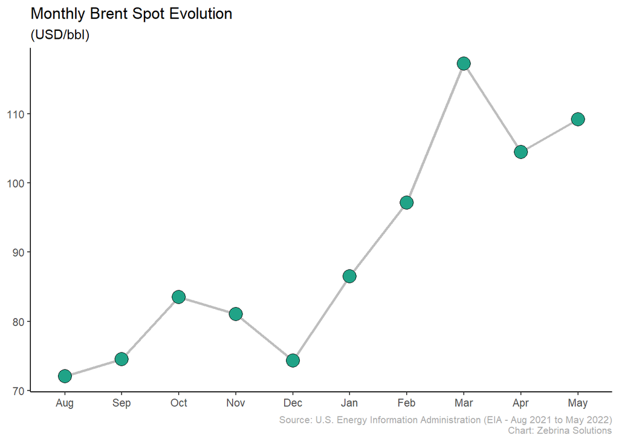

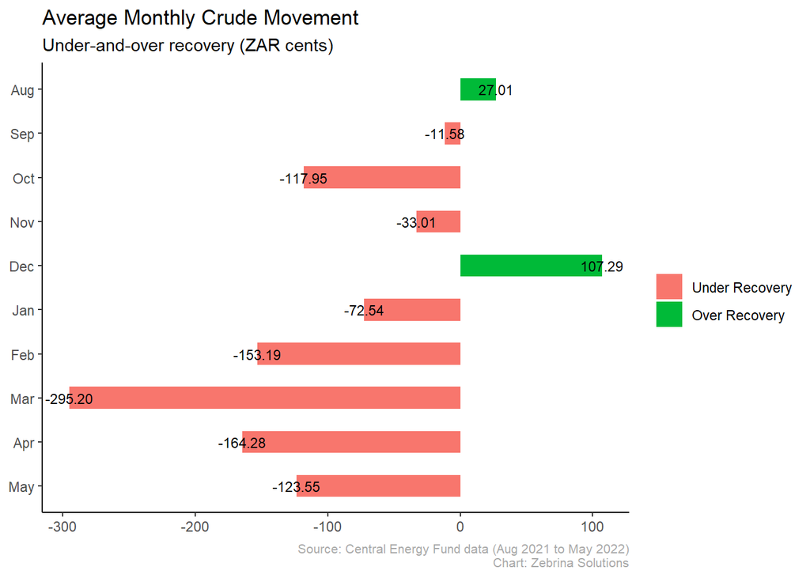

### **Basic Fuel Price (BFP)**

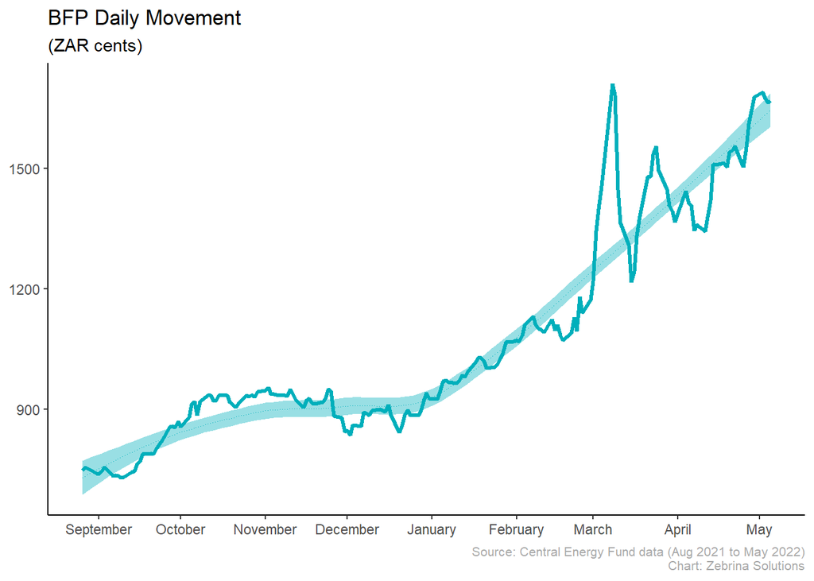

- The consolidated view of BFP showing continued ‘Under Recovery’, resulting in the subsequent increase in BFP and WSLP.

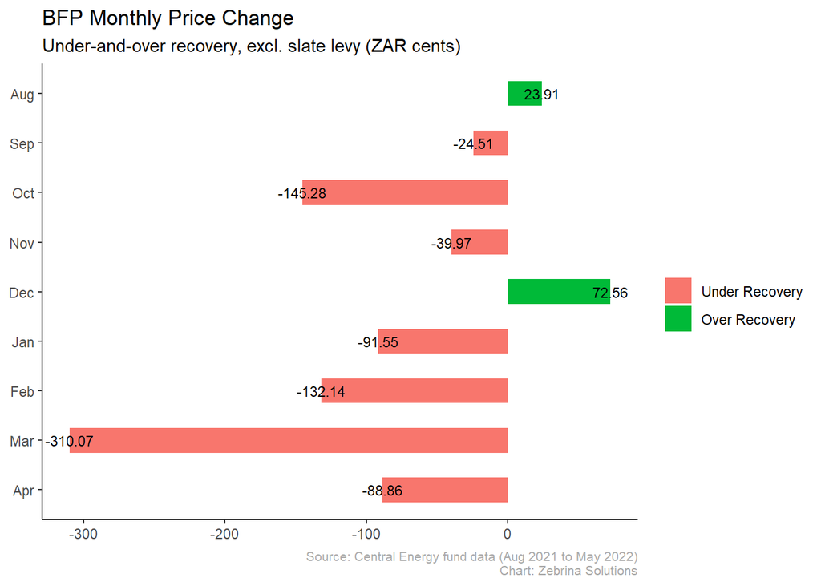

[figure not shown]

For any questions or comments, contact steve@zebrinasolutions.co.za

[www.zebrinasolutions.co.za](http://zebrinasolutions.co.za)